# Sums of Squares and Hypothesis Testing

Dr. Lucy D’Agostino McGowan

# Understanding Sums of Squares

## What Are We Measuring?

**The Big Picture:** How well does our model explain the data?

**Three key quantities:**  
- Total variation in the data  
- Variation explained by our model  
- Variation left unexplained (residuals)

## The Linear Model Reminder

**Our model:** $\mathbf{y} = \mathbf{X}\boldsymbol{\beta} + \boldsymbol{\varepsilon}$

**Fitted values:** $\hat{\mathbf{y}} = \mathbf{X}\hat{\boldsymbol{\beta}} = \mathbf{H}\mathbf{y}$

where $\mathbf{H} = \mathbf{X}(\mathbf{X}^T\mathbf{X})^{-1}\mathbf{X}^T$ is the “hat matrix”

**Residuals:** $\hat{\boldsymbol{\varepsilon}} = \mathbf{y} - \hat{\mathbf{y}}$

# Total Sum of Squares (TSS)

## What is TSS?

**Definition:** Total variation in the response variable $\mathbf{y}$

**Formula:**
$$\text{TSS} = \sum_{i=1}^n (y_i - \bar{y})^2$$

## What is TSS?

**Definition:** Total variation in the response variable $\mathbf{y}$

**Matrix form:**
$$\text{TSS} = (\mathbf{y} - \bar{y}\mathbf{1})^T(\mathbf{y} - \bar{y}\mathbf{1})$$

where $\mathbf{1}$ is a vector of ones and $\bar{y}$ is the sample mean

## TSS Intuition

**Think of TSS as:** “How spread out are my y-values?”

**Key insight:** This is what we’re trying to explain with our model

**Alternative matrix form:**
$$\text{TSS} = \mathbf{y}^T\mathbf{y} - n\bar{y}^2$$

## TSS

$$\mathbf{y}^T\mathbf{y}-\mathbf{y}^T\bar{y}\mathbf{1}-\bar{y}\mathbf{1}^T\mathbf{y}+\bar{y}^T\bar{y}$$

**Given:** $\mathbf{y} = \begin{bmatrix} 2 \\ 4 \\ 6 \\ 8 \end{bmatrix}$

**Find:** TSS using both the definition and matrix form

`03:00`

## You Try: Setup

**Step 1:** Calculate $\bar{y} = \frac{2+4+6+8}{4} = 5$

**Step 2:** Deviations from mean: $\begin{bmatrix} -3 \\ -1 \\ 1 \\ 3 \end{bmatrix}$

## You Try: Solution

**Method 1 (definition):**
$$\text{TSS} = (-3)^2 + (-1)^2 + 1^2 + 3^2 = 9 + 1 + 1 + 9 = 20$$

**Method 2 (matrix form):**
$$\text{TSS} = 2^2 + 4^2 + 6^2 + 8^2 - 4(5^2) = 120 - 100 = 20$$

# Sum of Squared Errors (SSE)

## What is SSE?

**Definition:** Variation left **unexplained** by our model

**Formula:**
$$\text{SSE} = \sum_{i=1}^n (y_i - \hat{y}_i)^2 = \sum_{i=1}^n \hat{\varepsilon}_i^2$$

## What is SSE?

**Definition:** Variation left **unexplained** by our model

**Matrix form:**
$$\text{SSE} = \hat{\boldsymbol{\varepsilon}}^T\hat{\boldsymbol{\varepsilon}} = (\mathbf{y} - \hat{\mathbf{y}})^T(\mathbf{y} - \hat{\mathbf{y}})$$

## SSE with Hat Matrix

**Since $\hat{\mathbf{y}} = \mathbf{H}\mathbf{y}$:**
$$\text{SSE} = (\mathbf{y} - \mathbf{H}\mathbf{y})^T(\mathbf{y} - \mathbf{H}\mathbf{y})$$

**Factor out $\mathbf{y}$:**
$$= \mathbf{y}^T(\mathbf{I} - \mathbf{H})^T(\mathbf{I} - \mathbf{H})\mathbf{y}$$

## SSE with Hat Matrix

**Key property:** $\mathbf{I} - \mathbf{H}$ is symmetric and idempotent
$$\text{SSE} = \mathbf{y}^T(\mathbf{I} - \mathbf{H})\mathbf{y}$$

## SSE Intuition

**Think of SSE as:** “How much did we miss with our model?”

**Smaller SSE =** Better fit  
**Larger SSE =** Worse fit

**Perfect fit:** SSE = 0 (model explains everything)

# Model Sum of Squares ($\textrm{SS}_\textrm{Reg}$)

## What is Regression Sum of Squares?

**Definition:** Variation **explained** by our model

**Formula:**
$$\text{SS}_{\text{Reg}} = \sum_{i=1}^n (\hat{y}_i - \bar{y})^2$$

## What is Regression Sum of Squares?

**Definition:** Variation **explained** by our model

**Matrix form:**
$$\text{SS}_{\text{Reg}} = (\hat{\mathbf{y}} - \bar{y}\mathbf{1})^T(\hat{\mathbf{y}} - \bar{y}\mathbf{1})$$

## Regression SS with Hat Matrix

**Since $\hat{\mathbf{y}} = \mathbf{H}\mathbf{y}$:**
$$\text{SS}_{\text{Reg}} = (\mathbf{H}\mathbf{y} - \bar{y}\mathbf{1})^T(\mathbf{H}\mathbf{y} - \bar{y}\mathbf{1})$$

**Alternative form:**
$$\text{SS}_{\text{Reg}} = \mathbf{y}^T\mathbf{H}\mathbf{y} - n\bar{y}^2$$

## Regression Sum of Squares Intuition

**Think of $\textrm{SS}_\textrm{Reg}$ as:** “How much variation did our model capture?”

**Larger $\textrm{SS}_\textrm{Reg}$ =** Model explains more  
**Smaller $\textrm{SS}_\textrm{Reg}$ =** Model explains less

**No model:** $\textrm{SS}_\textrm{Reg}$ = 0 (just predicting the mean)

# The Fundamental Identity

## It all adds up!

**The key relationship:**
$$\text{Total Variation} = \text{Unexplained} + \text{Explained}$$

## You Try: Prove the Identity

**Challenge:** Show that TSS = SSE + $\textrm{SS}_\textrm{Reg}$ using matrix algebra

**Hint:** Start with the definitions and use properties of the hat matrix

`05:00`

## Proof Strategy

**Start with:** TSS = $\mathbf{y}^T\mathbf{y} - n\bar{y}^2$

**Key insight:** We need to decompose $\mathbf{y}$ as $\mathbf{y} = \hat{\mathbf{y}} + \hat{\boldsymbol{\varepsilon}}$

**Then show:** Cross terms vanish due to orthogonality

## Proof: Step by Step

**Write:** $\mathbf{y} = \hat{\mathbf{y}} + \hat{\boldsymbol{\varepsilon}} = \mathbf{H}\mathbf{y} + (\mathbf{I}-\mathbf{H})\mathbf{y}$

**Then:**
$$\mathbf{y}^T\mathbf{y} = (\mathbf{H}\mathbf{y} + (\mathbf{I}-\mathbf{H})\mathbf{y})^T(\mathbf{H}\mathbf{y} + (\mathbf{I}-\mathbf{H})\mathbf{y})$$

## Expand the Product

**Four terms:**
$$= \mathbf{y}^T\mathbf{H}^T\mathbf{H}\mathbf{y} + \mathbf{y}^T\mathbf{H}^T(\mathbf{I}-\mathbf{H})\mathbf{y}$$
$$+ \mathbf{y}^T(\mathbf{I}-\mathbf{H})^T\mathbf{H}\mathbf{y} + \mathbf{y}^T(\mathbf{I}-\mathbf{H})^T(\mathbf{I}-\mathbf{H})\mathbf{y}$$

## Cross Terms Vanish

**Key property:** $\mathbf{H}(\mathbf{I}-\mathbf{H}) = \mathbf{0}$ (orthogonal projections)

**Therefore:** The cross terms equal zero

**Result:**
$$\mathbf{y}^T\mathbf{y} = \mathbf{y}^T\mathbf{H}\mathbf{y} + \mathbf{y}^T(\mathbf{I}-\mathbf{H})\mathbf{y}$$

## Final Identity

**Subtract $n\bar{y}^2$ from both sides:**
$$\text{TSS} = \text{SS}_{\text{Reg}} + \text{SSE}$$

**Beautiful result:** Total variation splits perfectly into explained and unexplained parts

# Coefficient of Determination (R²)

## What is R²?

**Definition:** Proportion of total variation explained by the model

**Formula:**
$$R^2 = \frac{\text{SS}_{\text{Reg}}}{\text{TSS}} = 1 - \frac{\text{SSE}}{\text{TSS}}$$

**Range:** $0 \leq R^2 \leq 1$

## R² Interpretation

**R² = 0.8** means “80% of variation is explained by the model”

**Perfect fit:** R² = 1 (model explains everything)  
**No relationship:** R² = 0 (model explains nothing)

**Warning:** High R² doesn’t always mean good model!

## You Try: Calculate R²

**Given:** TSS = 100, SSE = 25

**Find:** R² and interpret the result

`02:00`

## You Try: Solution

**Method 1:**
$$R^2 = 1 - \frac{\text{SSE}}{\text{TSS}} = 1 - \frac{25}{100} = 0.75$$

**Method 2:**
$$\text{SS}_{\text{Reg}} = \text{TSS} - \text{SSE} = 100 - 25 = 75$$
$$R^2 = \frac{75}{100} = 0.75$$

**Interpretation:** The model explains 75% of the variation in y

# The Danger of R²: Anscombe’s Quartet

## When R² Misleads

```r
# Load the famous Anscombe's Quartet
data(anscombe)

# All have same R²!
lm1 <- lm(y1 ~ x1, data = anscombe)
lm2 <- lm(y2 ~ x2, data = anscombe)
lm3 <- lm(y3 ~ x3, data = anscombe)
lm4 <- lm(y4 ~ x4, data = anscombe)

c(summary(lm1)$r.squared, summary(lm2)$r.squared,
  summary(lm3)$r.squared, summary(lm4)$r.squared)
```

```
[1] 0.6665425 0.6662420 0.6663240 0.6667073
```

## Visual Reality Check

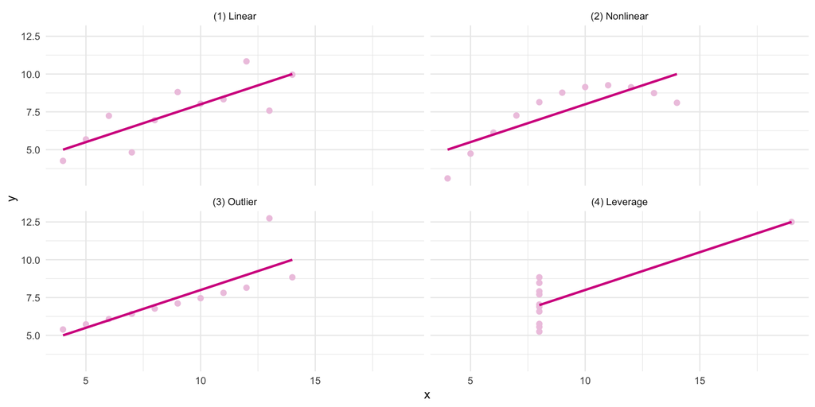

# Hypothesis Testing in Matrix Form

## The Big Questions

**Single predictor:** Is $\beta_1$ significantly different from 0?

**Multiple predictors:** Are any of the predictors useful?

**Subset test:** Is a group of predictors jointly significant?

## Testing Single Coefficients

**Null hypothesis:** $H_0: \beta_j = 0$  
**Alternative:** $H_1: \beta_j \neq 0$

**Test statistic:**
$$t = \frac{\hat{\beta}_j}{\text{se}(\hat{\beta}_j)}$$

**Standard error:** $\text{se}(\hat{\beta}_j) = \sqrt{\hat{\sigma}^2[(\mathbf{X}^T\mathbf{X})^{-1}]_{jj}}$

## Where Does the Standard Error Come From?

**Recall:** $\text{Var}(\hat{\boldsymbol{\beta}}) = \sigma^2(\mathbf{X}^T\mathbf{X})^{-1}$

**For individual coefficient j:**
$$\text{Var}(\hat{\beta}_j) = \sigma^2[(\mathbf{X}^T\mathbf{X})^{-1}]_{jj}$$

**Estimate $\sigma^2$:** $\hat{\sigma}^2 = \frac{\text{SSE}}{n-p}$ where p = number of parameters

## t-Distribution Result

**Under normality assumption:**
$$\frac{\hat{\beta}_j - \beta_j}{\text{se}(\hat{\beta}_j)} \sim t_{n-p}$$

## t-Distribution Result

**For testing $H_0: \beta_j = 0$:**
$$t = \frac{\hat{\beta}_j}{\text{se}(\hat{\beta}_j)} \sim t_{n-p}$$

# Overall F-Test

## Testing Multiple Predictors

**Null hypothesis:** $H_0: \beta_1 = \beta_2 = \cdots = \beta_{p-1} = 0$

**Alternative:** At least one $\beta_j \neq 0$ (j ≠ 0)

**This tests:** “Is the model useful at all?”

## F-Test Statistic

**Test statistic:**
$$F = \frac{\text{SS}_{\text{Reg}}/(p-1)}{\text{SSE}/(n-p)} = \frac{\text{Mean Square Regression}}{\text{Mean Square Error}}$$

**Under $H_0$:** $F \sim F_{p-1, n-p}$

## F-Test Intuition

**Numerator:** How much variation does model explain per parameter?

**Denominator:** How much unexplained variation per residual degree of freedom?

**Large F:** Model explains a lot relative to noise  
**Small F:** Model doesn’t explain much more than noise

## Connection to R²

**Alternative F-statistic form:**
$$F = \frac{R^2/(p-1)}{(1-R^2)/(n-p)}$$

**This shows:** F-test is really testing whether R² is significantly different from 0

# General Linear Hypothesis Testing

## The Framework

**General form:** $H_0: \mathbf{C}\boldsymbol{\beta} = \mathbf{d}$

**Where:**  
- $\mathbf{C}$ is a contrast matrix (q × p)  
- $\mathbf{d}$ is a vector of constants  
- q is the number of restrictions

## Examples of Linear Hypotheses

**Single coefficient:** $\mathbf{C} = [0, 1, 0, 0]$, $\mathbf{d} = 0$  
Tests: $\beta_1 = 0$

**Overall test:** $\mathbf{C} = \begin{bmatrix} 0 & 1 & 0 & 0 \\ 0 & 0 & 1 & 0 \\ 0 & 0 & 0 & 1 \end{bmatrix}$, $\mathbf{d} = \mathbf{0}$  
Tests: All slope coefficients = 0

**Equality test:** $\mathbf{C} = [0, 1, -1, 0]$, $\mathbf{d} = 0$  
Tests: $\beta_1 = \beta_2$

## The General F-Test

**Test statistic:**
$$F = \frac{(\mathbf{C}\hat{\boldsymbol{\beta}} - \mathbf{d})^T[\mathbf{C}(\mathbf{X}^T\mathbf{X})^{-1}\mathbf{C}^T]^{-1}(\mathbf{C}\hat{\boldsymbol{\beta}} - \mathbf{d})/q}{\text{SSE}/(n-p)}$$

**Under $H_0$:** $F \sim F_{q, n-p}$

## You Try: Set Up Hypothesis Test

**Scenario:** Three predictors, want to test if the last two coefficients are both zero

**Model:** $y = \beta_0 + \beta_1 x_1 + \beta_2 x_2 + \beta_3 x_3 + \varepsilon$

**Question:** What are $\mathbf{C}$ and $\mathbf{d}$ for $H_0: \beta_2 = \beta_3 = 0$?

`03:00`

## You Try: Solution

**Answer:**
$$\mathbf{C} = \begin{bmatrix} 0 & 0 & 1 & 0 \\ 0 & 0 & 0 & 1 \end{bmatrix}, \quad \mathbf{d} = \begin{bmatrix} 0 \\ 0 \end{bmatrix}$$

**Check:** $\mathbf{C}\boldsymbol{\beta} = \begin{bmatrix} \beta_2 \\ \beta_3 \end{bmatrix} = \begin{bmatrix} 0 \\ 0 \end{bmatrix}$ ✓

# Putting It All Together

## The ANOVA Table

| Source | df | Sum of Squares | Mean Square | F |
| --- | --- | --- | --- | --- |
| Regression | p-1 | $\textrm{SS}_\textrm{Reg}$ | $\textrm{MS}_\textrm{Reg}$ | $\textrm{MS}_\textrm{Reg}$/MSE |
| Error | n-p | SSE | MSE |  |
| Total | n-1 | TSS |  |  |

## Matrix Summary

**Key relationships:**  
- TSS = $\mathbf{y}^T\mathbf{y} - n\bar{y}^2$  
- $\textrm{SS}_\textrm{Reg}$ = $\mathbf{y}^T\mathbf{H}\mathbf{y} - n\bar{y}^2$  
- SSE = $\mathbf{y}^T(\mathbf{I} - \mathbf{H})\mathbf{y}$  
- TSS = $\textrm{SS}_\textrm{Reg}$ + SSE

**R² = $\textrm{SS}_\textrm{Reg}$/TSS = 1 - SSE/TSS**

## Testing Hierarchy

**Step 1:** Overall F-test (is model useful?)

**Step 2:** Subset F-tests (are groups of predictors significant?)

**Step 3:** Individual t-tests (which predictors matter?)

# Understanding P-values in Regression

## What is a P-value?

**Definition:** The probability of observing a test statistic as extreme or more extreme than what we observed, assuming the null hypothesis is true

**In other words:** “How surprising is our result if $H_0$ were true?”

## P-values for t-tests

**For testing $H_0: \beta_j = 0$:**

**Test statistic:** $t = \frac{\hat{\beta}_j}{\text{se}(\hat{\beta}_j)}$

**Two-sided p-value:**

$$\text{p-value} = P(|T| \geq |t|) = 2 \times P(T \geq |t|)$$
where $T \sim t_{n-p}$

## P-values for F-tests

**For overall test $H_0:$ all slopes = 0:**

**Test statistic:** $F = \frac{\text{SS}_{\text{Reg}}/(p-1)}{\text{SSE}/(n-p)}$

**One-sided p-value:**

$$\text{p-value} = P(F_{p-1,n-p} \geq f)$$
where $f$ is our observed F-statistic

## You Try: Interpret P-values

**Scenario:** Testing $H_0: \beta_1 = 0$ with t = 2.8 and df = 18

**Given:** p-value = 0.012

**Questions:**

- What does this p-value mean?
- Would you reject $H_0$ at α = 0.05?
- Would you reject $H_0$ at α = 0.01?

`03:00`

## You Try: Solution

**Interpretation:** If $\beta_1 = 0$ were true, there’s only a 1.2% chance of seeing a t-statistic as extreme as ±2.8 or more extreme

**At α = 0.05:** Reject $H_0$ (p = 0.012 < 0.05) - Evidence suggests $\beta_1 \neq 0$

**At α = 0.01:** Fail to reject $H_0$ (p = 0.012 > 0.01) - Not enough evidence at this stricter level

# Computing P-values in R

## The Key Functions

**For t-tests:** Use `pt()` function

**For F-tests:** Use `pf()` function

**Both give:** Cumulative distribution function (CDF) values

## t-test P-values with `pt()`

**Two-sided test:** $H_0: \beta_j = 0$

```r
# Example: t = 2.8, df = 18
t_stat <- 2.8
df <- 18

# Two-sided p-value
p_value_t <- 2 * (1 - pt(abs(t_stat), df))
p_value_t
```

```
[1] 0.01183672
```

## t-test P-values with `pt()`

**Why the formula?**

- `pt(2.8, 18)` gives P(T ≤ 2.8)
- `1 - pt(2.8, 18)` gives P(T > 2.8)
- Multiply by 2 for both tails

## F-test P-values with `pf()`

**One-sided test:** $H_0:$ all slopes = 0

```r
# Example: F = 12.44, df1 = 3, df2 = 16
f_stat <- 12.44
df1 <- 3  # numerator df (p-1)
df2 <- 16 # denominator df (n-p)

# One-sided p-value
p_value_f <- 1 - pf(f_stat, df1, df2)
p_value_f
```

```
[1] 0.0001879013
```

```r
# One-sided p-value
p_value_f <- pf(f_stat, df1, df2, lower.tail = FALSE)
p_value_f
```

```
[1] 0.0001879013
```

## F-test P-values with `pf()`

**Why one-sided?** F-statistics are always ≥ 0, so we only care about the right tail

## You Try: Calculate P-values

**Given:** - t-statistic = -1.96, df = 24 - F-statistic = 8.5, df1 = 2, df2 = 20

**Calculate both p-values using R**

`03:00`

## You Try: Solution

```r
# t-test p-value (two-sided)
t_val <- -1.96
df_t <- 24
p_t <- 2 * pt(abs(t_val), df_t, lower.tail = FALSE)
cat("t-test p-value:", round(p_t, 4))
```

```
t-test p-value: 0.0617
```

```r
# F-test p-value (one-sided)
f_val <- 8.5
df1_f <- 2
df2_f <- 20
p_f <- pf(f_val, df1_f, df2_f, lower.tail = FALSE)
cat("\nF-test p-value:", round(p_f, 4))
```

```
F-test p-value: 0.0021
```

## P-value Cautions

**What p-values DON’T tell us:**

- How large or important the effect is
- Whether the relationship is causal
- Whether the model assumptions are met

**Remember:** Statistical significance ≠ practical significance

**Best practice:** Report both p-values AND effect sizes ($\hat{\beta}_j$)

## Key Takeaways

**P-values help us:**

- Quantify evidence against $H_0$
- Make consistent decisions about significance
- Communicate strength of statistical evidence

**But remember:**

- Context matters more than arbitrary cutoffs
- Consider effect size alongside significance
- Check model assumptions first

## Final You Try: Complete Analysis

**Given:** n = 20, p = 4, TSS = 1000, SSE = 300

**Calculate:**  
- R²  
- Overall F-statistic  
- Conclude at α = 0.05 level

`05:00`

## Final Solution

**R² calculation:**
$$R^2 = 1 - \frac{SSE}{TSS} = 1 - \frac{300}{1000} = 0.7$$

**F-statistic:**
$$F = \frac{SS_{Reg}/(p-1)}{SSE/(n-p)} = \frac{700/3}{300/16} = \frac{233.33}{18.75} = 12.44$$

**Critical value:** $F_{0.05, 3, 16} = 3.24$

**Conclusion:** Reject $H_0$. The model is statistically significant.